# Group 2 Peer Review Summary

## Booze ‘R’ Us Summary

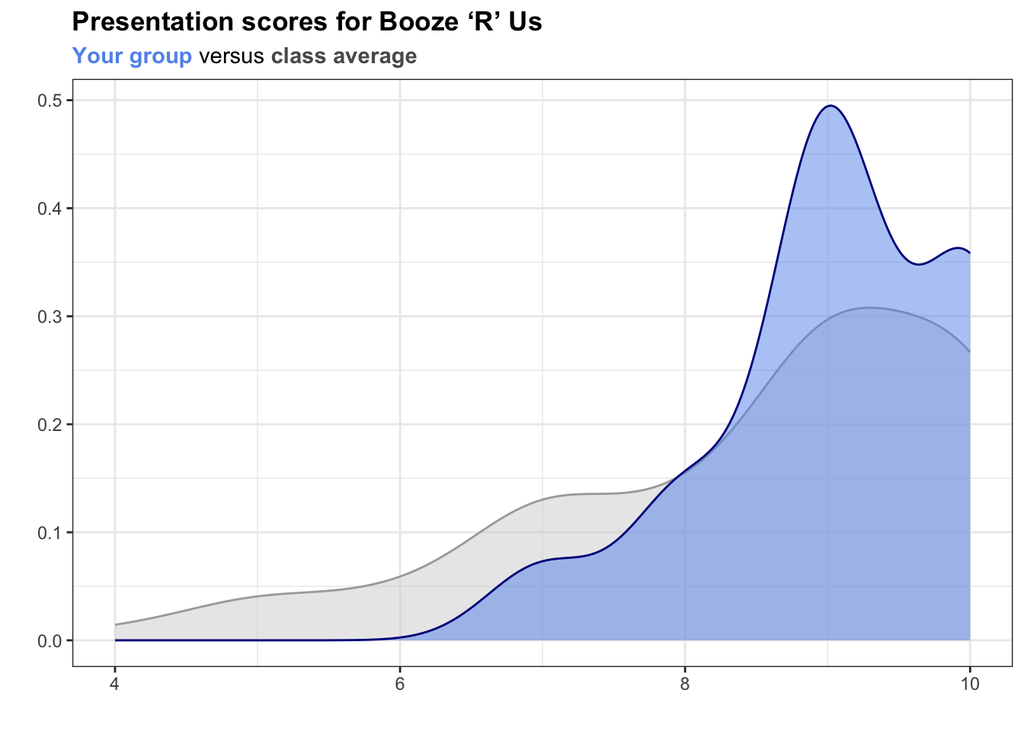

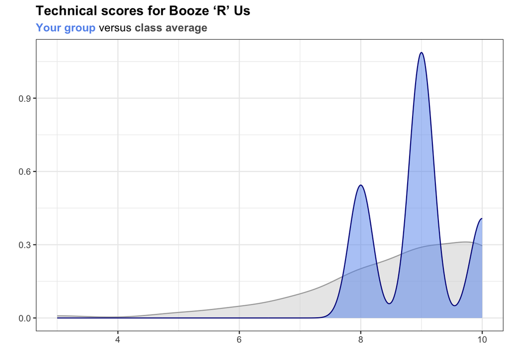

## D.E.A.D Summary

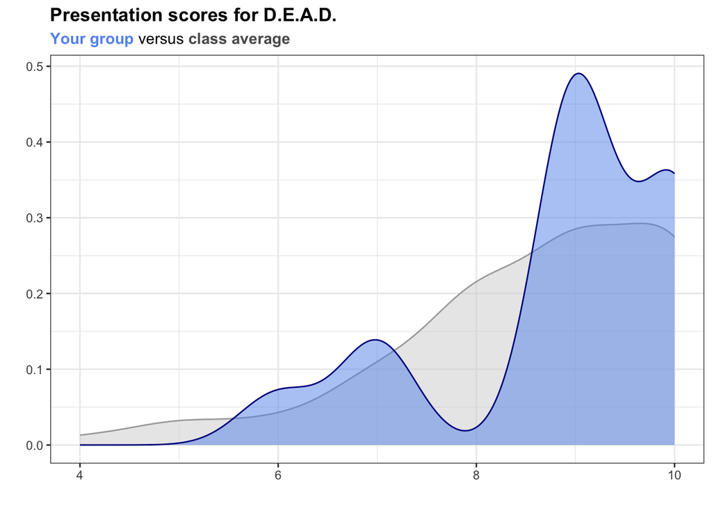

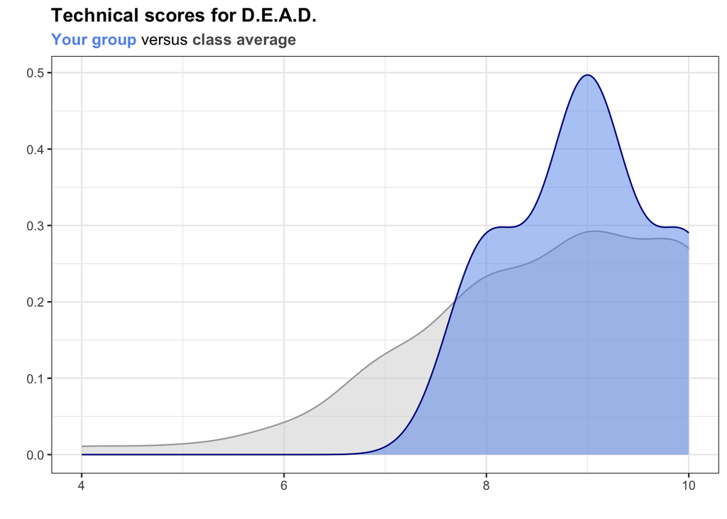

## Constructive Critiques

- I think both groups could have gone deeper on the issue of their model.
- I thought the plot with the slope coefficients was confusing
- The visuals with the rectangles was a little confusing and hard to follow.
- Didn’t specify model performance metrics
- The matrix plots (?) were difficult to read/understand.
- Booze R Us should have explained their magnitude graph because it was difficult to understand without the explanation that we didn’t get until the DEAD presentation.
- The category of alcohol purchased predictors were a bit confusing in the interpretation
- Plots shown about coefficient magnitude were difficult to interpret
- Could have made the final results more clear. I found it hard to understand their final sales predictors.
- Some parts felt like reading off a script, not very natural.
- Don’t look at slides/notes as often
- The group provided a lot of info on each slide so sometimes it was difficult to keep up
- For Booze R Us, looking in to only one store in particular may not be the most helpful for the client, stores in general may be the better approach
- Perhaps reading less off slides
- Not having too much text was good, but some of the slides were hard to follow along because a lot of information was conveyed verbally without enough visuals or text to help us process what we are listening to

## Compliments

- I liked the plot on the magnitude of the coefficients.
- I really liked how the models you tried to fit were included in addition to the final model
- Really good job on the slides. Not too many details that it was distracting.
- All spoke professionally
- You crafted a story that was very smoothly and articulately told.
- DEAD did a great job speaking in depth while still keeping it engaging.
- Everyone always kept it relevant to the clients and tied everything into the conclusion well
- Loved conclusions of how the clients can use the models for their benefit. Made everything come together
- Good job on the data visualization.
- Minimized a lot of unnecessary elements and technical jargon, only important information was covered which made it very easy to follow and understand.
- Slides and presentation look really polished!!
- Presenters did really well explaining applications of models
- The visualizations were excellent and introductions were very good in emphasizing the goals of the projects
- The visuals and explanations were phenominal and understandable
- Slides look nice without too much text